# 第13回 線形回帰と最小二乗法

経済学基礎数学II

第13回

線形回帰と最小二乗法

いちばんよく合う線の公式を、自分で導いて使う

経済学基礎数学II

第13回 — Topic01

線形回帰の使い所

ばらついた点に合う直線を、数で決める

## 第13回の道のり

1

使い所

要点 ずれの $2$ 乗の合計 $S$

2

公式を導く

要点 $a$ と $b$ の公式

3

回帰係数を出す

演習 3-1 回帰直線の計算

いまココ — ばらついた点に、いちばんよく合う線を $1$ 本引く

## 前回までの振り返り

前に手に入れた道具

Q: この回で使う道具は、何だったか

- **偏微分**：動かさない文字を数だと思って微分する  
  例 $x^2 + 3xy$ を $x$ で偏微分すると $2x + 3y$
- **$1$ 階の条件**：谷の底や山の頂では、どちらの向きの傾きも $0$
- **合成関数の微分 — 外、中、かける**  
  例 $(3x + 1)^5$ を微分すると $5(3x + 1)^4 \times 3$

どれも、よく合う線を探す所で使う  
この $3$ つで足りる。**新しい数学は $1$ つも足さない**

## 線形回帰の使い所

[figure not shown]

広告費と売上・気温と飲み物の売上・駅からの距離と家賃。  
関係はありそうだが、**点は一直線には並ばない**

直線 $y = ax + b$ は春に見た。でも、  
全部の点を通る直線は引けない。**どの線を引けばよいか**

## 直線から読める $2$ つのこと

[figure not shown]

① まだ出したことのない広告費でも、売上を見込める  
② 広告費が $1$ 万円多い月は、売上が平均していくら高いか

ゼミや卒業研究でデータを扱うと、この線（回帰直線）がそのまま出てくる

## 目分量で引いた $3$ 本の候補

ある店の $5$ か月 広告費 $x$：$0,\ 10,\ 20,\ 30,\ 40$（万円）  
売上 $y$：$50,\ 50,\ 120,\ 110,\ 170$（万円）

[figure not shown]

候補 A $y = 2x + 60$・B $y = 3x + 30$・C $y = 4x + 30$、どれもそれらしい  
**「よく合う」を数で決めたい**。数なら、誰が計算しても同じ線

## 残差の定義

定義 — 残差（ざんさ）

$$y_i - (ax_i + b)$$

- **$i$**：何番目の点かの番号（この店では $1$ から $5$）
- **$x_i$・$y_i$**：$i$ 番目の点の広告費と、実際の売上（同じ月の組）
- **$a$・$b$**：直線の傾きと切片。この $2$ つで直線が決まる
- **$ax_i + b$**：直線 $y = ax + b$ が、$i$ 番目の点で出す**予想**
- **残差**：実際 $-$ 予想。「残りのずれ」という意味

この向きに決めると、直線より上にある点の残差は正、下にある点は負

## 残差の測り方

[figure not shown]

候補 A に対する残差。**線に直角に下ろすのではなく、真上・真下に測る**。  
$y$ の予想がどれだけ外れたかを見るため

## ⚠ 合計で打ち消し合う残差

✕ 残差をそのまま足す

候補 A の残差（前の図の棒）  
$-10,\ -30,\ 20,\ -10,\ 30$

$-10 - 30 + 20 - 10 + 30 = 0$

水平な線 $y = 100$ の残差  
$-50,\ -50,\ 20,\ 10,\ 70$ も合計 $0$  
合計では $1$ 本に決まらない

○ 符号を消してから足す

正と負のずれが  
打ち消し合わないようにする

消し方は $2$ つ  
絶対値 $\lvert -10 \rvert = 10$  
$2$ 乗 $(-10)^2 = 100$

**符号を消したい**。絶対値と $2$ 乗の、どちらを使うか

## $2$ 乗を選ぶ理由

[figure not shown]

図は棒 $1$ 本ぶん。実際は $5$ 本ぶんの合計を、$a$ と $b$ を動かして小さくする  
全部の $r$ を $0$ にはできないので、合計の底を「傾きが $0$」の場所で探す

絶対値は角で微分できない  
**$2$ 乗なら、知っている微分がそのまま使える**

## 残差の $2$ 乗の合計 $S$

定義 — 残差の $2$ 乗の合計 $S$

$$S = \sum_{i=1}^{n}\bigl(y_i - ax_i - b\bigr)^2$$

$n = 5$ なら $S = (y_1 - ax_1 - b)^2 + (y_2 - ax_2 - b)^2 + \cdots + (y_5 - ax_5 - b)^2$

- **読み**：$\sum$ は「シグマ」。$i = 1$ から $n$ まで足す。$n$ は点の数で、この店では $5$
- **言葉で**：残差 $y_i - (ax_i + b)$ の括弧を外す（マイナスが中に入る）。  
  それを $2$ 乗して足す。**小さいほどよく合う**
- **名前**：$S$ をいちばん小さくする直線を選ぶ決め方を、**最小二乗法**という

## 候補 A の $S$ の計算

| $x$ | $y$ | 予想 $2x + 60$ | 残差 | $2$ 乗 |
| --- | --- | --- | --- | --- |
| $0$ | $50$ | $60$ | $-10$ | $100$ |
| $10$ | $50$ | $80$ | $-30$ | $900$ |
| $20$ | $120$ | $100$ | $20$ | $400$ |
| $30$ | $110$ | $120$ | $-10$ | $100$ |
| $40$ | $170$ | $140$ | $30$ | $900$ |
|  |  |  | 合計 | $\mathbf{2400}$ |

B $y = 3x + 30$・C $y = 4x + 30$ も同じ手順で（答えだけ） B $1900$・C $2900$  
**$3$ 本では B がいちばん小さい**

では、$S$ をいちばん小さくする線は、どう探すか

## まとめ

- 線が $1$ 本あれば、見込みと「$1$ 増えたときの違い」が言える
- 残差は「実際 $-$ 予想」。**縦に測る**
- 足すと打ち消し合う。微分できるように **$2$ 乗してから足す**
- $S = \sum(y_i - ax_i - b)^2$ 小さいほどよく合う（最小二乗法）

「よく合う」は $S$ の小ささで決まる。残った問いは、$S$ をいちばん小さくする $a$ と $b$  
これを次のトピックで見る

経済学基礎数学II

第13回 — Topic02

線形回帰の公式を導く

$S$ を $a$ と $b$ で偏微分して 0 とおく

## 第13回の道のり

1

使い所

要点 ずれの $2$ 乗の合計 $S$

2

公式を導く

要点 $a$ と $b$ の公式

3

回帰係数を出す

演習 3-1 回帰直線の計算

いまココ — ★ この回の山場。  
$S$ をいちばん小さくする $a$ と $b$ の公式を、自分で導く

## 残差の $2$ 乗の合計 $S$ の復習

前のトピックのポイント — トピック1「線形回帰の使い所」

Q: 「よく合う」を、どんな数で決めたか

- **残差**：実際 $-$ 予想。縦に測る
- **$S = \sum(y_i - ax_i - b)^2$**：$2$ 乗してから足す。小さいほどよく合う
- **候補 A・B・C**：$S$ は $2400$・$1900$・$2900$ で、  
  $3$ 本では B がいちばん小さい

でも、$a$ と $b$ はほかにいくらでも選べる  
$3$ 本を比べるだけでは、いちばん小さい線は分からない

## 動く文字と動かない文字

$S = \sum(y_i - ax_i - b)^2$ の文字を、止めておく数と動かす数に分ける

| 文字 | 中身 | 扱い |
| --- | --- | --- |
| $x_1, \ldots, x_5$ と $y_1, \ldots, y_5$ | 帳簿に書いてある $10$ 個の数 | **止めておく数** |
| $a$（傾き）と $b$（切片） | こちらが選ぶ $2$ つの数 | **動かす数（変数）** |

帳簿の数を入れると $S = (50 - b)^2 + (50 - 10a - b)^2 + \cdots$  
残る文字は $a$ と $b$ だけ

だから $S$ は **$a$ と $b$ の関数** $S(a, b)$  
前に出てきた $z = f(x, y)$ と同じ形。変数の文字が $a$, $b$ に変わっただけ

## 直線と $(a, b)$ の点の対応

[figure not shown]

候補 A は $(a, b) = (2, 60)$ の点。**線を選ぶことは、$(a, b)$ の点を選ぶこと**  
点ごとに $S$ が $1$ つ決まる。だから前と同じく、等高線の地図が描ける

## $S$ の等高線とおわんの底

[figure not shown]

中心が $1$ か所の楕円。前に出てきた**おわん**と同じ形

この図は、何万か所もの $(a, b)$ で $S$ を計算して描いた。手では無理  
**図を描かずに、底の $a$ と $b$ を式で出したい**

## 底を通る $2$ つの断面

[figure not shown]

底を通って、$a$ の向きと $b$ の向きに切った断面  
**どちらの断面も、底で接線が水平**

## ★ $S$ に当てる $1$ 階の条件

公式 — $1$ 階の条件（前に出てきたものをそのまま）

$$\frac{\partial S}{\partial a} = 0, \qquad \frac{\partial S}{\partial b} = 0$$

- **意味**：$a$ の向きにも $b$ の向きにも、傾きが $0$ になる。前に、谷の底を探した条件
- **記号**：前に出てきた偏微分の記号。動かすのは $a$ と $b$
- **本数**：式が $2$ 本、未知数が $2$ つ。  
  $x$ が全部同じでなければ、$a$ と $b$ は $1$ 組に決まる
- **谷の底か**：$S$ は $2$ 乗の合計なので、どの向きに切っても断面は谷の形の放物線。  
  だから傾きが $0$ の所は、その底だけ

## $b$ による偏微分

$S = \sum(y_i - ax_i - b)^2$ の $1$ 項ずつを $b$ で微分する。中は $b$ 以外を数とみる  
なぜ $b$ から？ $b$ は単独で入っていて、中を微分すると $-1$ だけ。いちばん簡単

$1$ 項

$\frac{\partial}{\partial b}(y_i - ax_i - b)^2 = 2(y_i - ax_i - b) \times (-1)$

外の微分 $\times$ 中の微分  
中は $0 - 0 - 1$

$\phantom{\frac{\partial}{\partial b}(y_i - ax_i - b)^2} = -2(y_i - ax_i - b)$

かける

合計

$\frac{\partial S}{\partial b} = -2\sum(y_i - ax_i - b) = 0$

$1$ 項ずつ足す  
共通の $-2$ は前へ

両辺を $-2$ で割る $\sum(y_i - ax_i - b) = 0$ ①

## 平均で表す切片 $b$

① の中の $\sum$ をばらして、平均の形に直す  
平均 $\bar x = \frac{\sum x_i}{n}$（エックス バー）、$\bar y = \frac{\sum y_i}{n}$（ワイ バー）

$\sum(y_i - ax_i - b) = \sum y_i - a\sum x_i - nb = 0$

① をばらす。  
共通の $a$ をくくる  
$b$ は $n$ 回足すので $nb$

$\bar y - a\bar x - b = 0$

$n$ で割る。  
$nb \div n = b$

$b = \bar y - a\bar x$

$b$ について解く

**$b$ が $a$ の式で書けた**。この店では $\bar x = 20$, $\bar y = 100$

## 平均の点を通る直線

[figure not shown]

$b = \bar y - a\bar x$ なら、$x = \bar x$ のとき $y = \bar y$ になる。**直線は平均の点を通る**  
でも、この点を通る線はいくらでもある。**傾き $a$ には、もう $1$ 本の式が要る**

## $a$ による偏微分

同じ手順を $a$ で。$b$ は数とみる  
$a$ は $x_i$ と組で入っているので、中を微分すると $-x_i$

$1$ 項

$\frac{\partial}{\partial a}(y_i - ax_i - b)^2 = 2(y_i - ax_i - b) \times (-x_i)$

外の微分 $\times$ 中の微分  
中は $0 - x_i - 0$

$\phantom{\frac{\partial}{\partial a}(y_i - ax_i - b)^2} = -2x_i(y_i - ax_i - b)$

かける

合計

$\frac{\partial S}{\partial a} = -2\sum x_i(y_i - ax_i - b) = 0$

$1$ 項ずつ足す  
共通の $-2$ は前へ

両辺を $-2$ で割る $\sum x_i(y_i - ax_i - b) = 0$ ②

## 代入法による $b$ の消去

$$\left\{
\begin{aligned}
\sum(y_i - ax_i - b) &= 0 \quad \text{①} \\
\sum x_i(y_i - ax_i - b) &= 0 \quad \text{②}
\end{aligned}
\right.
\qquad \text{① から}\ \ b = \bar y - a\bar x$$

$\sum x_i y_i - a\sum x_i^2 - b\sum x_i = 0$

② をばらす。$x_i \times y_i$, $x_i \times ax_i = ax_i^2$  
$x_i \times b$ は、どの項も同じ $b$ は前へ

$\sum x_i y_i - a\sum x_i^2 - b\,n\bar x = 0$

$\sum x_i$ を $n\bar x$ に書き直す（平均の $n$ 倍）

$\sum x_i y_i - a\sum x_i^2 - (\bar y - a\bar x)\,n\bar x = 0$

$b$ に $\bar y - a\bar x$ を入れる

$\sum x_i y_i - a\sum x_i^2 - n\bar x\bar y + a\,n\bar x^2 = 0$

括弧をほどく  
$-\bar y \times n\bar x$, $+a\bar x \times n\bar x$

## 傾き $a$ を解く式変形

前のページの最後の式 $\sum x_i y_i - a\sum x_i^2 - n\bar x\bar y + a\,n\bar x^2 = 0$  
これを $a$ について解く。$1$ 行で $1$ つの操作

$\sum x_i y_i - n\bar x\bar y = a\sum x_i^2 - a\,n\bar x^2$

$a$ の付いた $2$ つの項を右辺へ移す  
移すと符号が変わる

$\sum x_i y_i - n\bar x\bar y = a\bigl(\sum x_i^2 - n\bar x^2\bigr)$

右辺を $a$ でくくる

$a\bigl(\sum x_i^2 - n\bar x^2\bigr) = \sum x_i y_i - n\bar x\bar y$

左右を入れ替える

括弧で割れば $a$ が出る。括弧は $\sum(x_i - \bar x)^2$ に等しい（確かめは省く）  
$x$ が全部同じでなければ $0$ より大きいので、割ってよい

## ★ 回帰係数の公式

公式 — 回帰係数

$$a = \frac{\sum x_i y_i - n\bar x\bar y}{\sum x_i^2 - n\bar x^2}, \qquad b = \bar y - a\bar x$$

- **名前**：この $a$, $b$ を**回帰係数**、直線 $y = ax + b$ を**回帰直線**という
- **由来**：「平均へ戻る」という $19$ 世紀の言い方から。計算の中身とは関係がない
- **材料は $5$ つ**：$n$・$\bar x$・$\bar y$・$\sum x_i y_i$・$\sum x_i^2$
- **順番**：まず $a$、それから $b = \bar y - a\bar x$

## まとめ

- 動かせるのは $a$ と $b$ だけ。  
  $S(a, b)$ は変数が $2$ つある関数で、形はおわん
- 底では $\frac{\partial S}{\partial a} = 0$, $\frac{\partial S}{\partial b} = 0$（$1$ 階の条件）
- $b$ で微分すると $b = \bar y - a\bar x$ が出る。直線は平均の点を通る
- $a$ で微分して代入法で解くと、傾き $a$ の公式が出る
- 使った道具は偏微分・$1$ 階の条件・合成関数の微分。  
  $\sum$ は足し算を並べ替えただけ。**新しい数学は $0$**

回帰係数の公式が、前に持っていた道具だけで出た。残った問いは、  
実際に数を入れるとどうなるか  
これを次のトピックで見る

経済学基礎数学II

第13回 — Topic03

線形回帰の公式で  
回帰係数を出す

小さなデータで回帰直線を手で引く

## 第13回の道のり

1

使い所

要点 ずれの $2$ 乗の合計 $S$

2

公式を導く

要点 $a$ と $b$ の公式

3

回帰係数を出す

演習 3-1 回帰直線の計算

いまココ — 公式に数を入れて、回帰直線を自分の手で引く

## 回帰係数の公式の復習

公式 — 回帰係数（前のトピックで導いた）

$$a = \frac{\sum x_i y_i - n\bar x\bar y}{\sum x_i^2 - n\bar x^2}, \qquad b = \bar y - a\bar x$$

- **材料は $5$ つ**：点の数 $n$・平均 $\bar x$, $\bar y$・$\sum x_i y_i$・$\sum x_i^2$
- $\sum x_i y_i$ は $x$ と $y$ を掛けて全部足した数、$\sum x_i^2$ は $x$ を $2$ 乗して全部足した数
- **順番**：まず $a$、それから $b$（$b$ の式に $a$ が入っている）

でも、記号のままでは、線はまだ $1$ 本も引けていない  
材料を $1$ つずつ作って、公式に数を入れる

## ◼ 回帰直線の求め方

STEP は $4$ つ。材料を作る順に並べると、こうなる

1. **点の数 $n$ を数え、平均 $\bar x$ と $\bar y$ を出す**
2. **表を作り、$\sum x_i y_i$ と $\sum x_i^2$ を出す**
3. **分子と分母を別々に出してから割り、傾き $a$ を出す**
4. **$b = \bar y - a\bar x$ で切片 $b$ を出し、$y = ax + b$ と書く**

表の列は $x_i$・$y_i$・$x_i y_i$・$x_i^2$ の $4$ つで、いちばん下に合計の行  
このあとの演習 3-1 も、この STEP の番号どおりに解く

## 演習 3-1 回帰直線の計算

演習 3-1

STEP $1$〜$4$ で、回帰直線を手で求める

1. $x: 1,\ 2,\ 3$／$y: 2,\ 6,\ 7$ の回帰直線 $y = ax + b$ を求めよ

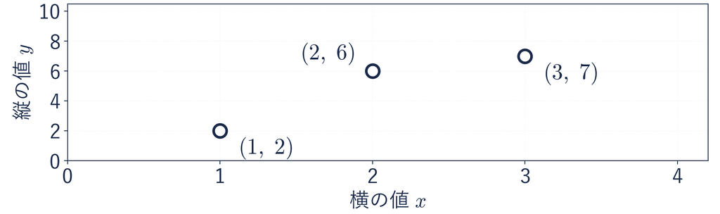

公式と STEP  
$a = \dfrac{\sum x_i y_i - n\bar x\bar y}{\sum x_i^2 - n\bar x^2}$, $b = \bar y - a\bar x$  
STEP $1$ 平均  
STEP $2$ 表（列 $x_i$・$y_i$・$x_i y_i$・$x_i^2$）  
STEP $3$ 分子と分母を出して割る  
STEP $4$ $b$ を出す

⏸ PAUSE 動画を止めて、ノートに表を作って解く。解けたら再生に戻る

## 演習 3-1 の答え STEP 1・2

**演習 3-1** $x: 1,\ 2,\ 3$／$y: 2,\ 6,\ 7$ の回帰直線 $y = ax + b$ を求めよ

STEP 1

$n = 3$, $\bar x = \frac{1 + 2 + 3}{3} = 2$, $\bar y = \frac{2 + 6 + 7}{3} = 5$

点は $3$ つ。  
足して $3$ で割る

| $x_i$ | $y_i$ | $x_i y_i$ | $x_i^2$ |
| --- | --- | --- | --- |
| $1$ | $2$ | $2$ | $1$ |
| $2$ | $6$ | $12$ | $4$ |
| $3$ | $7$ | $21$ | $9$ |
| 合計 $6$ | $15$ | $\mathbf{35}$ | $\mathbf{14}$ |

STEP 2

$\sum x_i y_i = 2 + 12 + 21 = 35$

先にかけてから縦に足す

$\sum x_i^2 = 1 + 4 + 9 = 14$

先に $2$ 乗してから縦に足す

## 演習 3-1 の答え STEP 3・4

材料 $n = 3$, $\bar x = 2$, $\bar y = 5$, $\sum x_i y_i = 35$, $\sum x_i^2 = 14$

STEP 3

分子 $= 35 - 3 \times 2 \times 5 = 35 - 30 = 5$

$\sum x_i y_i - n\bar x\bar y$ に入れる

分母 $= 14 - 3 \times 2^2 = 14 - 12 = 2$

$\sum x_i^2 - n\bar x^2$ に入れる。  
$2$ 乗は $\bar x$ だけ（$2^2 = 4$）

$a = \frac{5}{2} = 2.5$

最後に割る

STEP 4

$b = 5 - 2.5 \times 2 = 5 - 5 = 0$

$b = \bar y - a\bar x$ に入れる

こたえ

$y = 2.5x$（切片が $0$ なので $+\,0$ は書かない）

## 答えの直線と平均の点

[figure not shown]

確かめ $x = \bar x = 2$ を入れると $2.5 \times 2 = 5$ で、ちょうど $\bar y$ になる  
$b = \bar y - a\bar x$ なので、  
どのデータでも $x = \bar x$ なら $y = \bar y$ になる。**線は平均の点を通る**  
$b$ の書き間違いは、この確かめで見つかる

## 広告データの回帰直線

広告費 $x$：$0,\ 10,\ 20,\ 30,\ 40$ 売上 $y$：$50,\ 50,\ 120,\ 110,\ 170$（万円）

STEP 1・2

$n = 5$, $\bar x = 20$, $\bar y = 100$, $\sum x_i y_i = 13000$, $\sum x_i^2 = 3000$

材料

STEP 3

$a = \frac{13000 - 5 \times 20 \times 100}{3000 - 5 \times 20^2} = \frac{3000}{1000} = 3$

分子と分母を出して割る

STEP 4

$b = 100 - 3 \times 20 = 40$

$b = \bar y - a\bar x$

[figure not shown]

$y = 3x + 40$ ずれ（点と線の縦の差）を $2$ 乗して足すと $S = 1400$  
目分量の $3$ 本、候補 A $2400$・B $1900$・C $2900$ のどれより小さい

## 傾き $3$ の読み方

[figure not shown]

この線の上では、**広告費が $1$ 万円多い月は、売上が平均して $3$ 万円高い**  
切片 $40$ は、広告費 $0$ の月の売上の見込みが $40$ 万円（実際は $50$）

⚠ 「広告費を $1$ 万円増やせば、売上が $3$ 万円増える」とまでは言っていない  
線が表すのは、広告費が多い月と少ない月を比べた違い  
増やした結果の約束ではない

## 第13回のまとめ

- 回帰直線は STEP $4$ つで引ける。  
  平均 → 表 → 分子と分母を別々に出して $a$ → $b = \bar y - a\bar x$
- $3$ 点の例は $y = 2.5x$ になった。店のデータは $y = 3x + 40$ で、  
  $S = 1400$ は目分量の $3$ 本より小さい
- 傾き $3$ は比べる文で読む  
  「線の上では、広告費が $1$ 万円多い月は、売上が $3$ 万円高い」
- この回の道具は偏微分・$1$ 階の条件・合成関数の微分の $3$ つ  
  ここでは平均と表で数を入れただけ。**新しい数学は $0$**
- 練習はこの動画の演習 3-1 を、STEP の順に解き直す

この回の $1$ 文 ずれの $2$ 乗の合計 $S$ を $a$ と $b$ の関数と見て、  
$1$ 階の条件を当てると、回帰係数の公式が出てくる  
そこに数を入れれば、いちばんよく合う線が自分の手で引ける